# Прогнозирование оттока клиентов

#### Постройте распределения признаков для кластеров. Можно ли что-то заметить по ним?

```python
columns=df.columns
columns
```

```
Index(['gender', 'Near_Location', 'Partner', 'Promo_friends', 'Phone',
       'Contract_period', 'Group_visits', 'Age',
       'Avg_additional_charges_total', 'Month_to_end_contract', 'Lifetime',
       'Avg_class_frequency_total', 'Avg_class_frequency_current_month',
       'Churn', 'cluster_km'],
      dtype='object')
```

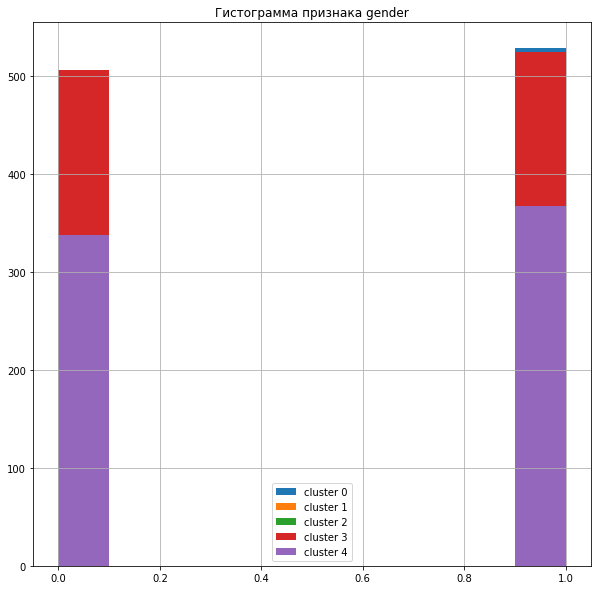

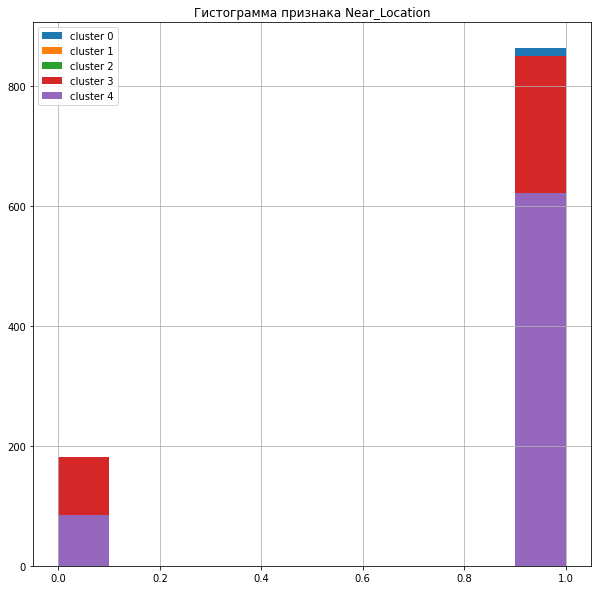

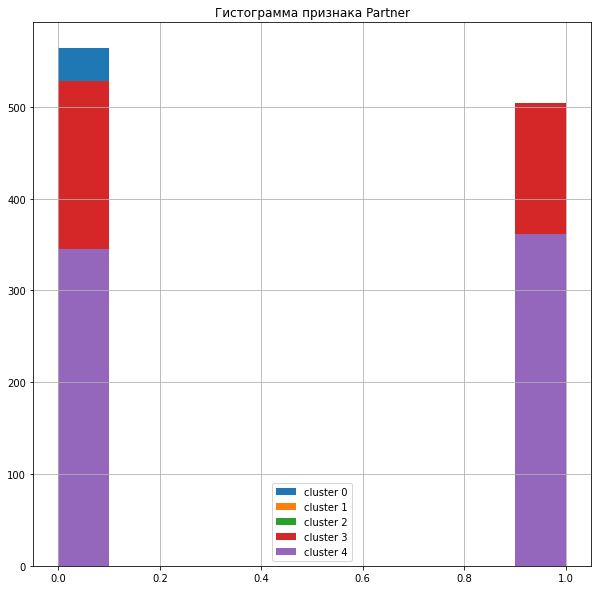

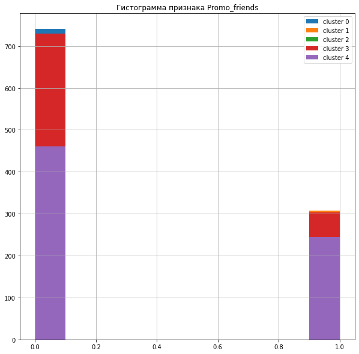

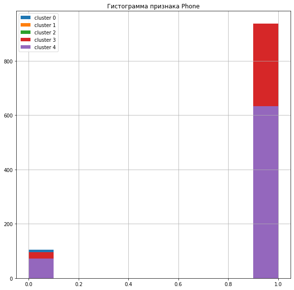

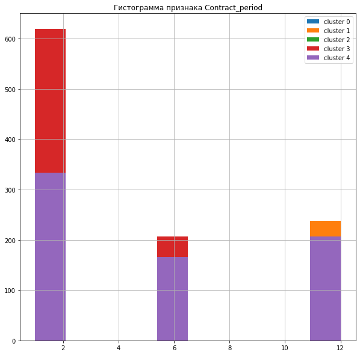

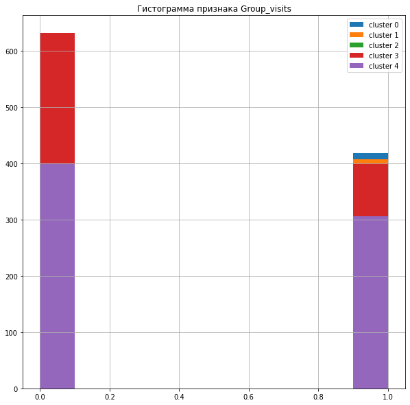

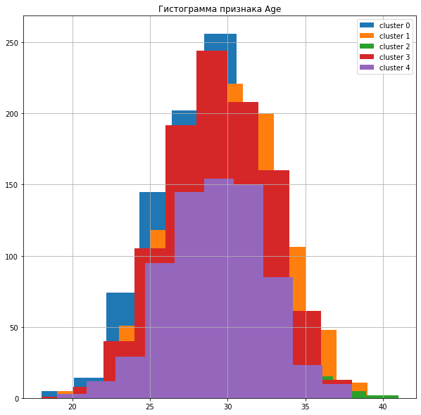

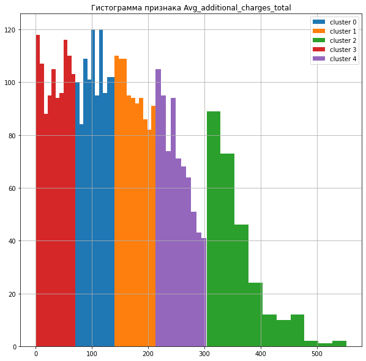

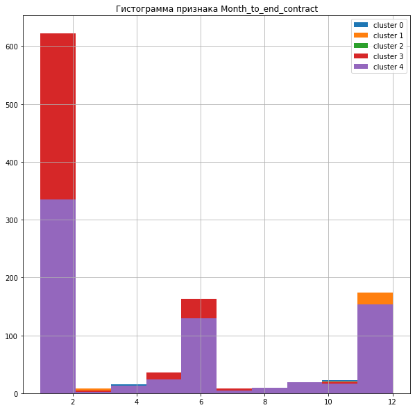

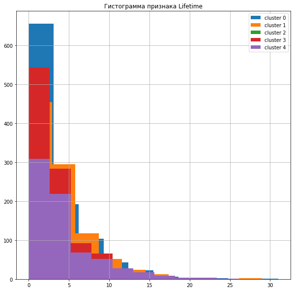

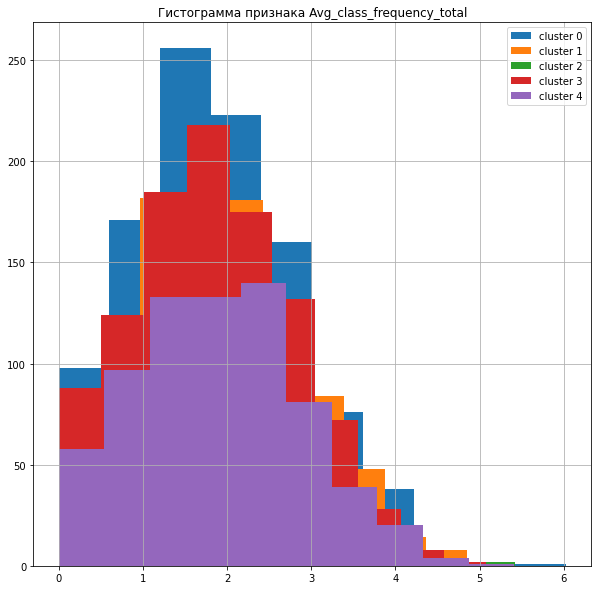

[3 more figures not shown]

```python
for column in columns: # построение гистограмм признаков для различных кластеров
    df.query('cluster_km == 0')[column].hist(label= 'cluster 0', figsize=(10,10))
    ax = df.query('cluster_km == 1')[column].hist(label= 'cluster 1',figsize=(10,10))
    ax = df.query('cluster_km == 2')[column].hist(label= 'cluster 2',figsize=(10,10))
    ax = df.query('cluster_km == 3')[column].hist(label= 'cluster 3',figsize=(10,10))
    ax = df.query('cluster_km == 4')[column].hist(label= 'cluster 4',figsize=(10,10))
    plt.title(f'Гистограмма признака {column}')
    plt.legend()
    plt.show()
```

Вывод: общий вид гистограмм не изменился после стандартизации и кластеризации.

#### Для каждого полученного кластера посчитайте долю оттока (методом groupby()). Отличаются ли они по доле оттока?

```python
#df3=df[['cluster_km', 'Churn']]
#df3.query('Churn==0').groupby('cluster_km')['Churn'].count().sort_values().plot(kind='pie',autopct='%.2f', figsize= (8,8))
#plt.title("Доля удержания клиенов по кластерам, %")
#plt.legend(title="Кластер")
#plt.show()
```

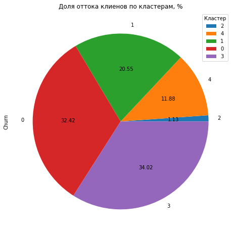

```python
df3=df[['cluster_km', 'Churn']]
df3.query('Churn==1').groupby('cluster_km')['Churn'].count().sort_values().plot(kind='pie',autopct='%.2f', figsize= (8,8))
plt.title("Доля оттока клиенов по кластерам, %")
plt.legend(title="Кластер")
plt.show()
```

Вывод: больше всего склонны к оттоку 3 и 0 кластеры. По средним характеристикам признаков для этих кластеров можно выделить, что в данных кластерах характерно более короткий контрактный период, меньше контрактов по промоакции, меньше расхода на дополнительные услуги фитнес клуба.

### Вывод

Сформируем советы для отдела маркетинга на основе данных исследования:

1. увеличение минимального контрактного периода до 5 месяцев, имеется ввиду, что клиент за короткий период абонемента не успевает проникнутся к спорту и с окончанием короткого абонемента больше его не продлевает;
2. продление промоакции для привлечения большего количества клиентов;
3. введение скидок и предложений на дополнительные услуги фитнес-центра на первых месяцах контракта для знакомства новых клиентов с услугами;
4. провести рекламу на дополнительные услуги фитнес-клуба, так как это может повлиять на рост продаж контрактов.